# Text Mining

Parnian Jahangiri Rad

3/19/2022

## Analysing Dickens books

We will use these libraries:

```r
library(tidyverse)
library(gutenbergr)
library(tidytext)
library(wordcloud2)
library(ragg)
library(graphics)
```

We will download all his novels using `gutenbergr` package.

#### Find 20 most common words in Dickens novels

After removing stop words, we will find 20 words that Dickens used most in his novels:

```r
x <- gutenberg_works(author == "Dickens, Charles")

books <- c("The Pickwick Papers",
           "Oliver Twist",
           "Nicholas Nickleby",
           "The Old Curiosity Shop",
           "Barnaby Rudge: A Tale of the Riots of 'Eighty",
           "Martin Chuzzlewit",
           "Dombey and Son",
           "David Copperfield",
           "Bleak House",
           "Hard Times",
           "Little Dorrit",
           "A Tale of Two Cities",
           "Great Expectations",
           "Our Mutual Friend",
           "The Mystery of Edwin Drood")

ids <- array(dim = length(books))
count <- 1
for (i in books){
  ids[count] <- x[x$title==i,"gutenberg_id"]$gutenberg_id
  count <- count + 1
}

dickens <- gutenberg_download(ids,mirror =  "http://mirrors.xmission.com/gutenberg/")

tidy_dickens <- dickens %>%
  unnest_tokens(word, text) %>%
  anti_join(stop_words)
td <- tidy_dickens %>%
  count(word, sort = TRUE) %>%
  mutate(word = reorder(word, n))
```

```r
td_20 <- td %>% top_n(20)
```

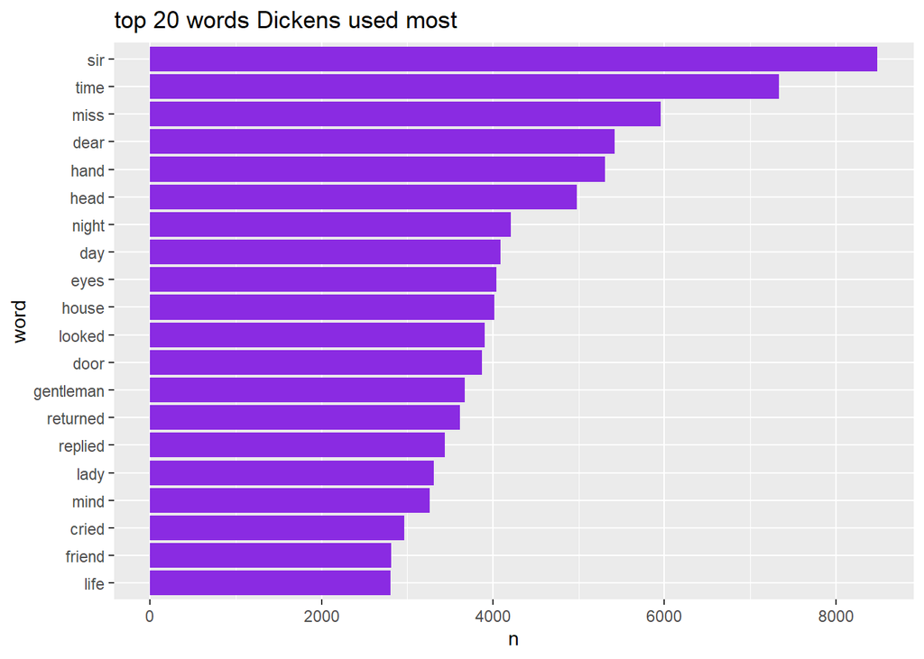

```r
ggplot(td_20,aes(x=n,y=word)) +
  geom_bar(stat = "identity",fill="blueviolet") +
  ggtitle("top 20 words Dickens used most")
```

#### Wordcloud of 200 most common words in Dickens novels

Now, we want to draw the wordcloud of 200 words that Dickens used most:

```r
td %>%
  arrange(desc(n)) %>%
  head(200) %>%
  wordcloud2(size = 1,
    shape = "circle",color = "random-dark",
    minRotation = pi/2, maxRotation = -pi/2, minSize = 10,
    rotateRatio = 1)
```

[interactive chart not shown]

#### Main characters of Dickens novels

In order to find the most important characters in the novels, first we will find the words with capital letters as their first letter. Then we will check if there is any mentions of that word while its first letter is lower case as well.If there is not, the word can be considered as a name.

```r
names <- dickens %>%
  unnest_tokens(word, text, to_lower = F) %>%
  mutate(word = str_extract(word, "[A-Z][a-z]+")) %>%
  na.omit()

words <- dickens %>%
  unnest_tokens(word, text, to_lower = F) %>%
  mutate(word = str_extract(word, "[a-z]+")) %>%
  na.omit()


names <- names[!str_to_lower(names$word) %in% words$word,]


names <- names %>%
  group_by(gutenberg_id) %>%
  filter((word!="Mr") & (word!="Mrs")) %>%
  count(word)

book_ids <- data.frame(ids, books)

characters <- tibble(names) %>%
  group_by(gutenberg_id) %>%
  mutate() %>%
  top_n(5)
for (id in book_ids$ids){
  characters[characters$gutenberg_id==id, "Book"] <- book_ids[book_ids$ids==id, "books"]
}
```

```r
characters <- characters %>%
  group_by(Book)
p <- ggplot(data = characters,
       aes(x = reorder(word,n) ,
           y = n ,
           fill = Book)) +
  geom_bar(stat = "identity") +
  coord_flip() +
  facet_wrap(.~Book, scales = 'free') +
  labs(x = NULL,y = NULL) +
  theme(axis.text.x = element_blank())
```

```r
pngfile <- fs::path(knitr::fig_path(),  "scaling.png")
agg_png(pngfile, width = 60, height = 36, units = "cm", res = 300, scaling = 2)
plot(p)
invisible(dev.off())
knitr::include_graphics(pngfile)
```

[figure not shown]

#### Find 10 most common verbs done by men and women

```r
dickens_4gram<- dickens %>%
  unnest_tokens(bigram, text, token = "ngrams", n = 4)
dickens_4gram_heshe <- dickens_4gram %>%
  separate(bigram, c("word1","word2","word3","word4"), sep=" ") %>%
  filter(word1=="he" | word1=="she") %>%
  filter(word2!="is" | (word2=="is" & (word3!="not" & word3!="a" & word3!="an") )) %>%
  filter(word2!="was" | (word2=="was" & (word3!="not" & word3!="a" & word3!="an") ))
dickens_4gram_heshe_backup <- dickens_4gram_heshe

aux <- tribble(~word,"had","have","has","was","is","would","could","did","might","should")
aux2 <- tribble(~word,"been","never")
dickens_4gram_heshe <- dickens_4gram_heshe_backup
dickens_4gram_heshe %>%
  mutate(second_word = ifelse(
    !(dickens_4gram_heshe$word2%in%aux$word),
     dickens_4gram_heshe$word2,ifelse(
        !(dickens_4gram_heshe$word3%in%aux2$word),
        dickens_4gram_heshe$word3,dickens_4gram_heshe$word4)))->dickens_4gram_heshe2
dickens_4gram_heshe2 %>%
  filter(second_word!="not"&second_word!="have"&second_word!="and"&second_word!="so") %>%
  filter(second_word!="a" & second_word!="an"&second_word!="will"&second_word!="be",) %>%
  filter(second_word!="the"&second_word!="were",second_word!="in") %>%
  group_by(word1,second_word) %>%
  summarise(count=n()) %>%
  ungroup() %>%
  group_by(word1) %>%
  arrange(desc(count)) %>%
  slice(1:10) %>%
  mutate(top=seq_along(word1))->dickens_4gram_heshe3
```

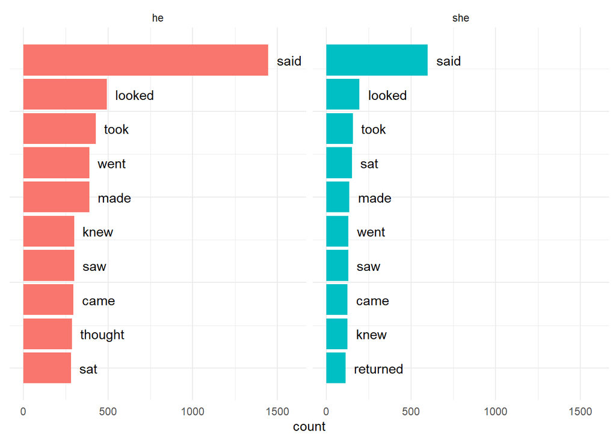

```r
ggplot(dickens_4gram_heshe3,aes(x=-top,y=count,fill=word1))+
  geom_bar(stat = "identity")+
  facet_wrap(. ~ word1)+
  geom_text(aes(y = count+50, label = second_word), hjust = "left")+
  coord_flip()+
  labs(x=NULL)+
  scale_y_continuous(limits = c(0,max(dickens_4gram_heshe3$count)*1.1))+
  theme_minimal()+
  theme(legend.position = 'none',
        axis.text.y = element_blank())
```